# exercise-09

Author

John Hinkle

## Step 1: Load data and packages

```r
library(tidyverse)
library(cowplot) # for making multi-panel figures
library(mosaic)
d <- read_csv("https://raw.githubusercontent.com/difiore/ada-datasets/main/KamilarAndCooperData.csv")
```

## Step 2: Plot lifespan vs female body mass

In plot 1 where both variables are untransformed, the relationship is **not** linear.

Log transforming the x variable (Female body mass) results in a linear relationship, and log transforming both variables appears to further strengthen the linear relationship.

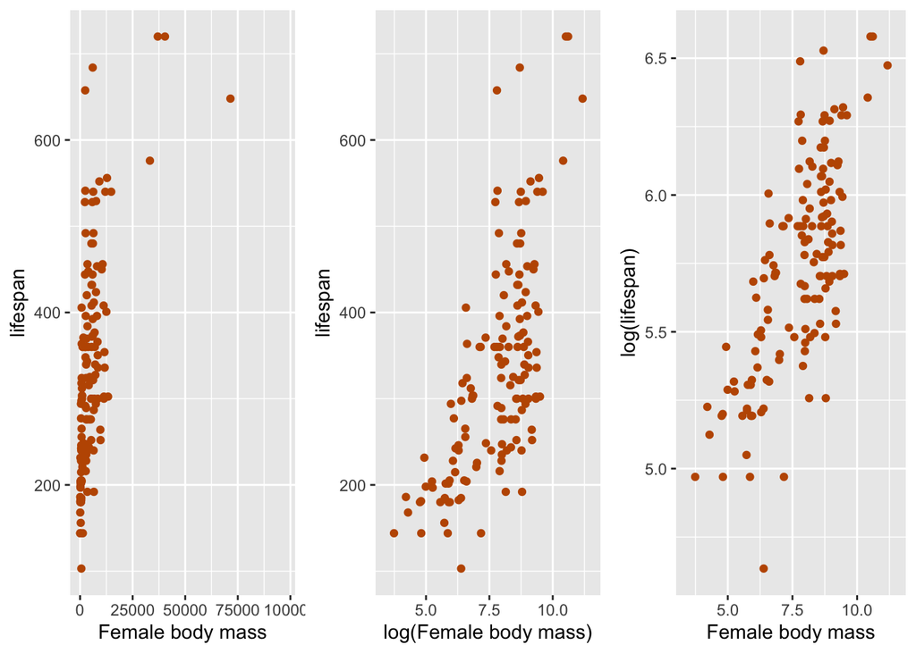

```r
# Female body mass vs lifespan
p1 <- ggplot(d, aes(x= Body_mass_female_mean, y = MaxLongevity_m)) +
  geom_point(color = "#bf5700") +
  labs(x = "Female body mass", y = "lifespan")

# log(Female body mass) vs lifespan
p2 <- ggplot(d, aes(x= log(Body_mass_female_mean), y = MaxLongevity_m)) +
  geom_point(color = "#bf5700") +
  labs(x = "log(Female body mass)", y = "lifespan")

# log(Female body mass) vs log(lifespan)
p3 <- ggplot(d, aes(x= log(Body_mass_female_mean), y = log(MaxLongevity_m))) +
  geom_point(color = "#bf5700") +
  labs(x = "Female body mass", y = "log(lifespan)")

# Plot Grid
plot_grid(p1, p2, p3, nrow = 1)
```

## Step 3: Run linear models

```r
# Model 1, lifespan vs Female body mass
m1 <- lm(MaxLongevity_m ~ Body_mass_female_mean, data = d)

# Model 2, lifespan vs log(Female body mass)
m2 <- lm(MaxLongevity_m ~ log(Body_mass_female_mean), data = d)

# Model 3, log(lifespan) vs log(Female body mass)
m3 <- lm(log(MaxLongevity_m) ~ log(Body_mass_female_mean), data = d)
```

## Step 4: Generate and manually plot residuals

The model 1 residuals are **not** normally distributed.

The model 2 residuals somewhat follow a normal distribution.

The model 3 residuals are the closest to following a normal distribution.

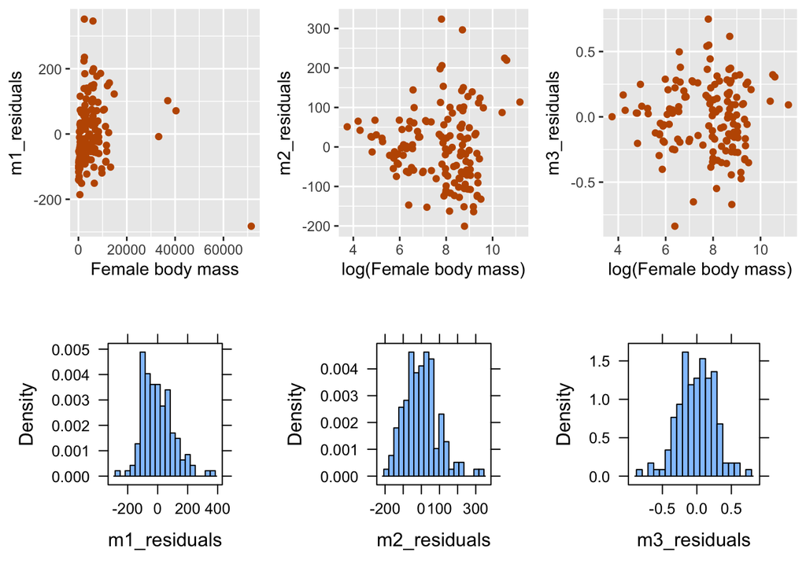

```r
# Extract residuals from each model
m1_residuals <- m1$residuals
m2_residuals <- m2$residuals
m3_residuals <- m3$residuals

# Model 1 Plot
m1_plot <- ggplot(data = NULL, aes(x= m1$model$Body_mass_female_mean, y = m1_residuals)) +
  geom_point(color = "#bf5700") +
  labs(x = "Female body mass")

# Model 2 Plot
m2_plot <- ggplot(data = NULL, aes(x= m2$model$`log(Body_mass_female_mean)`, y = m2_residuals)) +
  geom_point(color = "#bf5700") +
  labs(x = "log(Female body mass)")

# Model 3 Plot
m3_plot <- ggplot(data = NULL, aes(x= m3$model$`log(Body_mass_female_mean)`, y = m3_residuals)) +
  geom_point(color = "#bf5700") +
  labs(x = "log(Female body mass)")

# Model 1 Histogram
m1_hist <- histogram(m1_residuals, nint=20)

# Model 2 Histogram
m2_hist <- histogram(m2_residuals, nint=20)

# Model 3 Histogram
m3_hist <- histogram(m3_residuals, nint=20)

# Plot Grid
plot_grid(m1_plot, m2_plot, m3_plot, m1_hist, m2_hist, m3_hist, nrow = 2)
```

## Step 5: Q-Q Plots

As observed in the previous step, the model 3 residuals appear to follow a normal distribution.

The model 1 residuals clearly do **not** follow a normal distribution, and the model 2 residuals appear to **not** follow a normal distribution either.

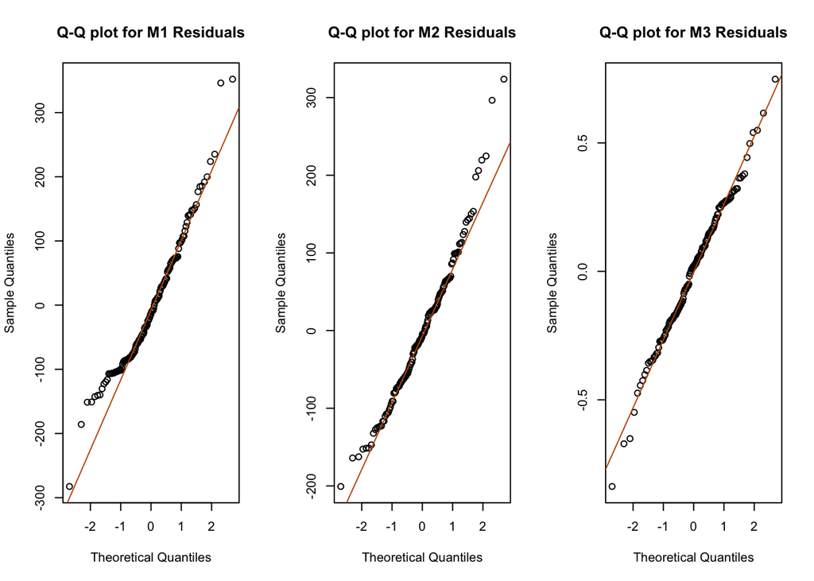

```r
par(mfrow=c(1, 3))

# Model 1 Q-Q Plot
qqnorm(m1_residuals, main="Q-Q plot for M1 Residuals")
qqline(m1_residuals, col = "#bf5700")

# Model 2 Q-Q Plot
qqnorm(m2_residuals, main="Q-Q plot for M2 Residuals")
qqline(m2_residuals, col = "#bf5700")

# Model 3 Q-Q Plot
qqnorm(m3_residuals, main="Q-Q plot for M3 Residuals")
qqline(m3_residuals, col = "#bf5700")
```

## Step 6: Linear Model Plots

These plots suggest that model 1 and model 2 both do not follow a normal distribution

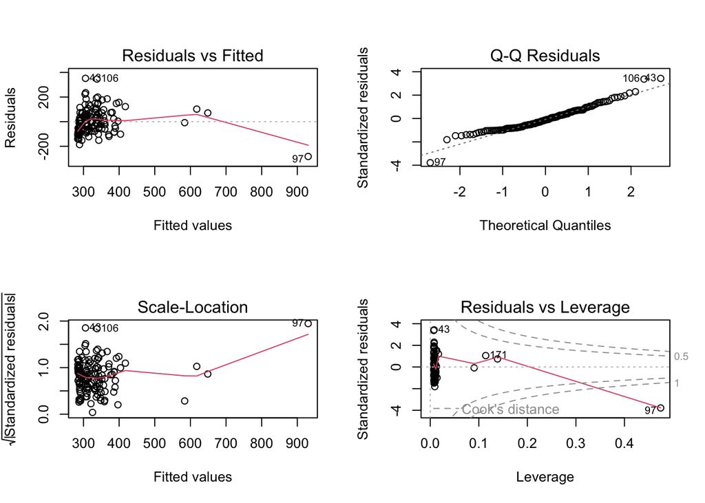

```r
# Model 1 Plots
par(mfrow = c(2, 2))
plot(m1)
```

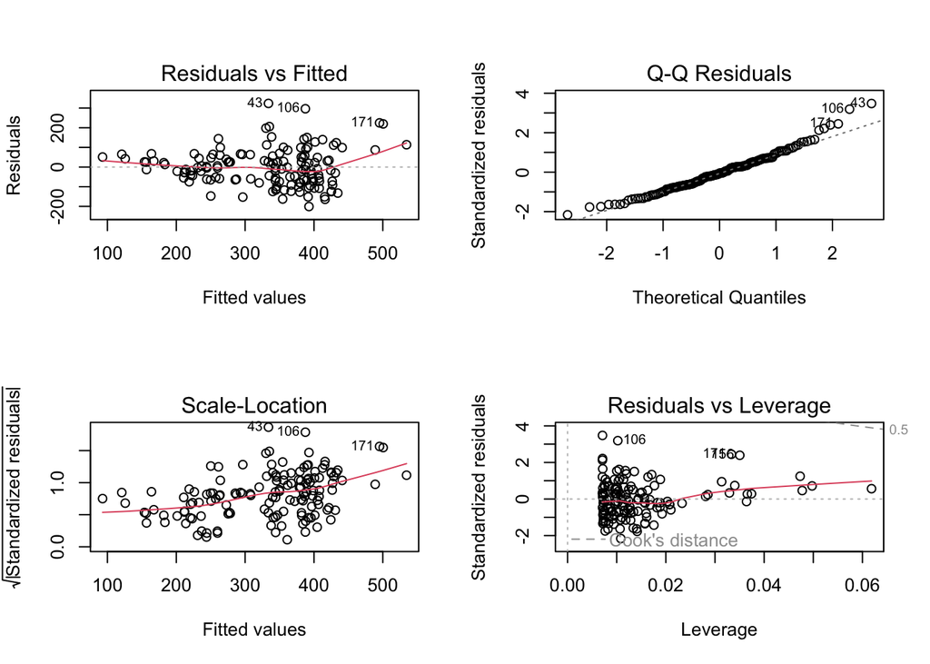

```r
# Model 2 Plots
par(mfrow = c(2, 2))
plot(m2)
```

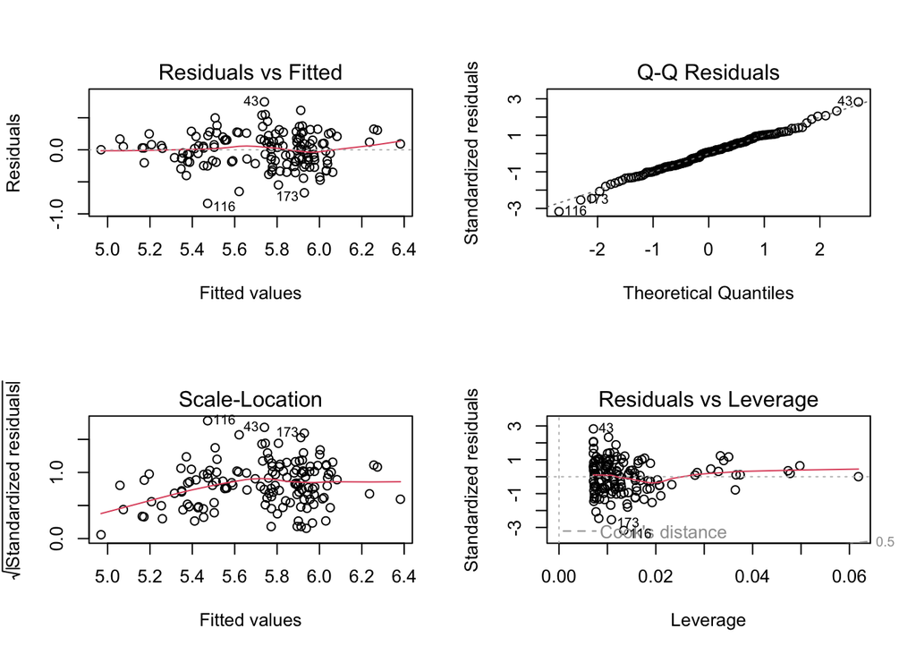

```r
# Model 3 Plots
par(mfrow = c(2, 2))
plot(m3)
```

## Step 7: Shapiro Test

The p-value for model 1 and model 2 is significant (p < 0.05), leading us to reject the null hypothesis that they follow a normal distribution.

The p-value for model 3 is not significant (p >>> 0.05), leading us to **not** reject the null hypothesis that they follow a normal distribution.

```r
# Model 1
shapiro.test(m1_residuals)
```

```
    Shapiro-Wilk normality test

data:  m1_residuals
W = 0.96352, p-value = 0.0008238
```

```r
# Model 2
shapiro.test(m2_residuals)
```

```
    Shapiro-Wilk normality test

data:  m2_residuals
W = 0.97515, p-value = 0.01131
```

```r
# Model 3
shapiro.test(m3_residuals)
```

```
    Shapiro-Wilk normality test

data:  m3_residuals
W = 0.99319, p-value = 0.7403
```